# 01_Introduction

Tobias Gerstenberg

1/7/2019

## Student feedback

> I appreciate knowing expectations about the course. Humor was also helpful. Having a date for the midterm and more details about the final project will be helpful as I plan my quarter. **Might be good to dive into some material, too**, although I imagine that’ll happen on Wednesday.

> I really appreciated that you gave an overview at the start of lecture of what we’ll be covering and the important points. It’s helpful to know what’s important to focus on. On the same note (and maybe it’s not so applicable to this lecture) it would be similarly helpful to **wrap up at the end with the biggest takeaways**.

> Great overview of what we will be learning. You come across as super approachable and knowledgeable. **I would have liked to know the length of the homework and the average amount of time you estimate us spending on: (a) homework, (b) readings + datacamp**. Also, I loved citing sources and the thank you slide!

> It was informative. **Next time it would be great if all deadlines for the midterm etc. would already be known by the first lecture**. In terms of setup of the class I think 2 longer lectures rather than 3 short ones per week would be better (less switching costs etc)

> I would have liked to hear more from you on **what you define to be ‘good science.’** For example, you alluded to replication, but beyond replication, what are some of your thoughts or philosophical orientation when it comes to conducting social science.

> I will be happy to get started with R and its exercises! It was the first lecture, **so it was slower than expected**. But I like how you made the class expectation clear to students! **But perhaps we can keep the first lecture shorter in length.**

> **It was nice to meet our neighbors.** I hope we keep having time and ways to meet others in class. It makes it easier to ask each other questions when the time comes. I like how many resources you list on the class website.

> Disliked: **no concepts today…**

|  | response |
| --- | --- |
| 1 | I appreciate knowing expectations about the course. Humor was also helpful. Having a date for the midterm and more details about the final project will be helpful as I plan my quarter. Might be good t… |
| 2 | Great introduction - I liked how it gave an overview of what to expect and the tools we will be using. Also like how Tobias was sensitive to different backgrounds and encouraged a growth mindset - hel… |
| 3 | I really appreciated that you gave an overview at the start of lecture of what we'll be covering and the important points. It's helpful to know what's important to focus on. On the same note (and mayb… |
| 4 | Great overview of what we will be learning. You come across as super approachable and knowledgeable. I would have liked to know the length of the homework and the average amount of time you estimate u… |
| 5 | It was informative. Next time it would be great if all deadlines for the midterm etc. would already be known by the first lecture. In terms of setup of the class I think 2 longer lectures rather than … |
| 6 | Great enthusiasm and positivity : ) |
| 7 | I would have liked to hear more from you on what you define to be 'good science.' For example, you alluded to replication, but beyond replication, what are some of your thoughts or philosophical orien… |
| 8 | Everything was very clear, and I like a brief note on all the things we can do on R. Overall presentation style was friendly and welcoming, which makes for greater enjoyment and easier understanding o… |
| 9 | I liked the relaxed attitude. I'm excited about the focus on R. I do have a couple logistical questions left unanswerd |
| 10 | Tobi, you have such a wonderful presence in front of the class. Your enthusiasm is contagious. Admittedly, I have very little experience in statistics, and I was nervous about coming here today. But a… |

[output cut: 27 more lines]

### PollEverywhere results

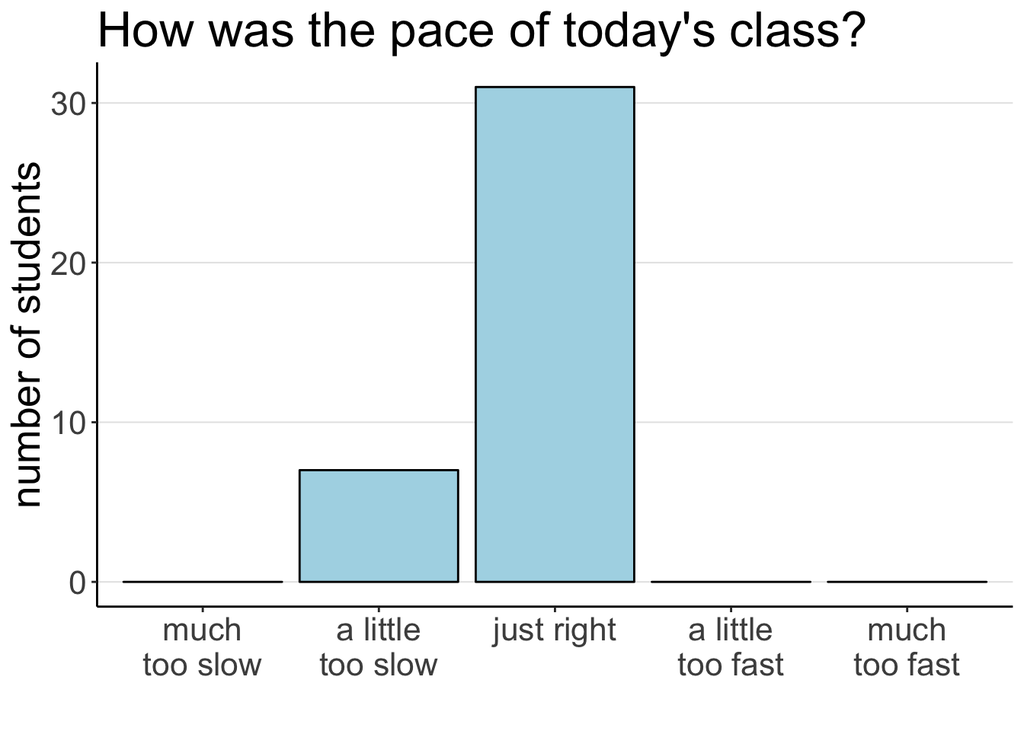

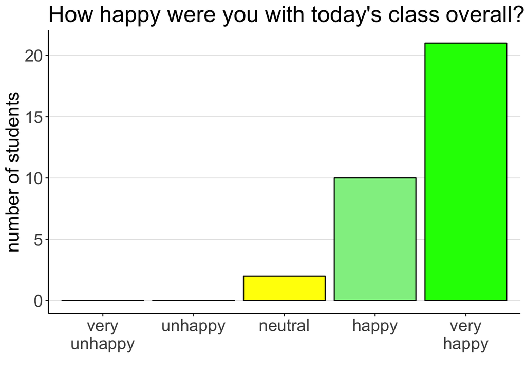

## What to do next time

- keep the interactive “introduce yourself to your neighbor” bit at the beginning
- keep the interactive feedback (polleverywhere)
- smoothen out the part about building models (with the Field figure, and the “Statistics as arguments” reference)
- introduce some conceptual material from the very beginning
  - a few fun statistics examples would be nice
  - maybe a worked example from my own research:
    - research question
    - statistical model
    - experiment
    - results
- have a slide the motivates the different tools:
  - a person in the middle, “Question about homework” –> Piazza; “Not feeling well” –> Office hour / email, …
- move some of the visualization content to the first lecture:
  - motivation for why visualization is so important
  - discuss some bad plots
- make clear that sections are a mandatory part of class
- make clear that they can call me “Tobi”